# Intro_R_Spatial_Tools

RMM

2023-09-22

### R Markdown

Both R and Python have libraries that can process files referred to as “shape files”. Details on the definition and development of the format can be read at [wikipedia] (https://en.wikipedia.org/wiki/Shapefile). An important thing to know is that whereas shape file refers to data that is used to represent geographical features, it needs 3 files to be operational.

### .shp

where coordinates of geographical features are kept.

### .shx

an indexing file for geometric features.

### .dbf

data that is associated with the geometric features. The folder we are going to download exists within the US Census Bureau website. From the website we navigate to where the [shape files for all the counties in USA are located](https://www2.census.gov/geo/tiger/TIGER2021/COUNTY/)

As you can see from the download, there are additional files present besides the .shp, .shx and .dbf. These are files that are not required for R and Python to create informative maps but we will keep them in our folder. In this project we make use of a multitude of spatial tools and functions for statistical analysis but for now we will focus only on the mapping aspects and the simple features, [sf package](https://r-spatial.github.io/sf/).

```r
# Loading the library, if you are using Windows you will have to make sure you have Rtools before being able to use the library -->
library(sf)
#We downloaded the shape zip folder, unzipped all the files in it to the data folder and read it in with the read_sf command-->
shape <- read_sf(dsn = "C:/Users/rm84/Desktop/research/HMM/data/tl_2021_us_county.shp")
#as can be seen from the dim command you have 3234 observations (counties) and 18 features associated with each county
dim(shape)
```

```
## [1] 3234   18
```

```r
#In R, objects have attributes. The shape object has 5 of these
length(attributes(shape))
```

```
## [1] 5
```

```r
#We will look at only the first attribute's values
attributes(shape)[1]
```

```
## $names
##  [1] "STATEFP"  "COUNTYFP" "COUNTYNS" "GEOID"    "NAME"     "NAMELSAD"
##  [7] "LSAD"     "CLASSFP"  "MTFCC"    "CSAFP"    "CBSAFP"   "METDIVFP"
## [13] "FUNCSTAT" "ALAND"    "AWATER"   "INTPTLAT" "INTPTLON" "geometry"
```

```r
#Names function will give us the values in the first attribute
names(shape)
```

```
##  [1] "STATEFP"  "COUNTYFP" "COUNTYNS" "GEOID"    "NAME"     "NAMELSAD"
##  [7] "LSAD"     "CLASSFP"  "MTFCC"    "CSAFP"    "CBSAFP"   "METDIVFP"
## [13] "FUNCSTAT" "ALAND"    "AWATER"   "INTPTLAT" "INTPTLON" "geometry"
```

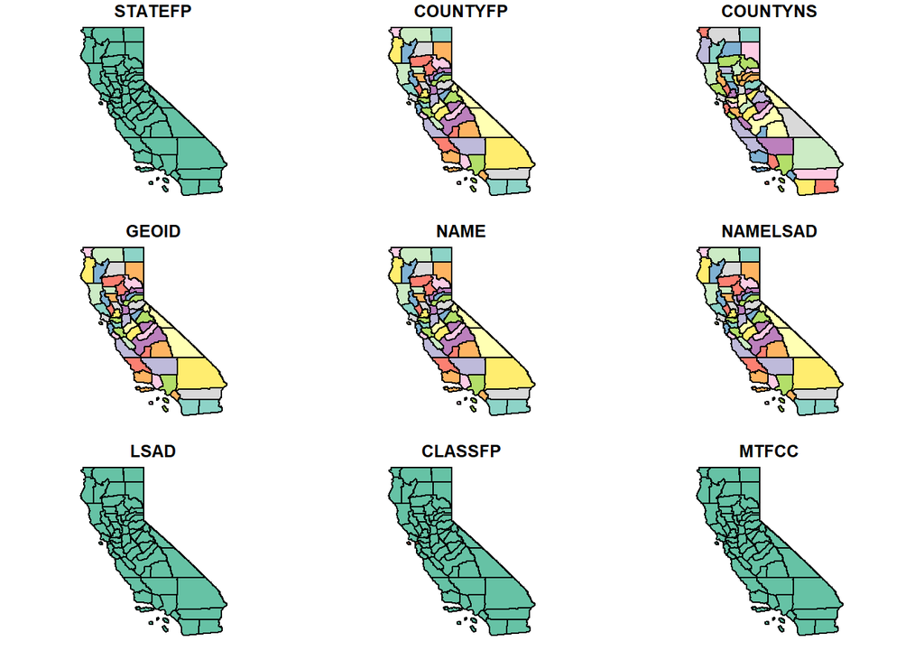

```r
#We will be working with only the Californian state
#selecting California via FIPS state code as you can see selection is done via base R via the %in% statement
shape=shape[(shape$STATEFP %in% '06'),]

#We could look at a very simple set of plots
plot(shape)
```

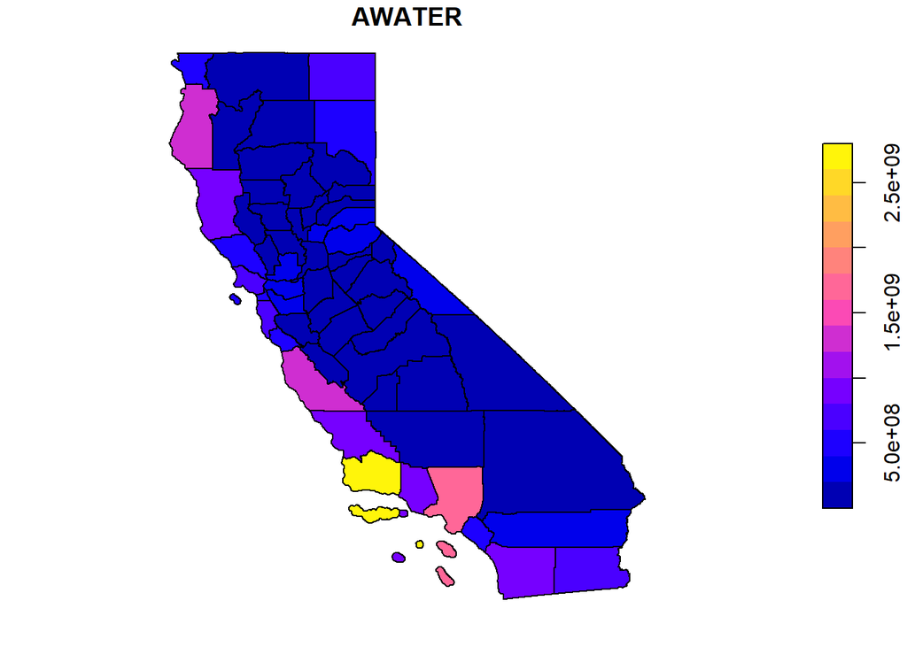

```r
#The shape function has 17 attributes and R chooses to plot a smaller number of them to fit the screen.


#We would rather do something a bit more useful and plot one of the attributes we are interested in
plot(shape[15])
```

```r
#Note that if you wrote plot(shape$AWATER) you get a scatterplot.
```

A good [vignette](https://r-spatial.github.io/sf/articles/) exists to explain the sf package.